# Data Cleaning Report

Generated using cuci) R package

Author

ykama

Published

## Overview

**Note**

This report summarises every column mapping decision made during the automated data cleaning pipeline. Rows flagged **Fuzzy** or **Predicted** require manual verification before the cleaned data is used for analysis.

### Summary

1

Datasets processed

300

Exact matches

0

Fuzzy matches ⚠

0

Predicted matches ⚠⚠

### Match Method Breakdown

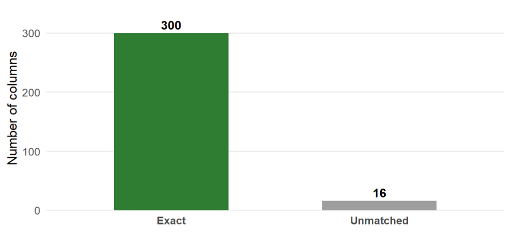

### Per-Dataset Summary

| Dataset | Year | Total | Exact | Fuzzy | Predicted | Unmatched | Needs Review |
| --- | --- | --- | --- | --- | --- | --- | --- |
| rus2026_hdir_fhi.csv | 2026 | 316 | 300 | 0 | 0 | 16 | 16 |

## Review Checklist

| Dataset | Year | Raw column | Mapped to | Method | Type | Action |
| --- | --- | --- | --- | --- | --- | --- |
| rus2026_hdir_fhi.csv | 2026 | skjema_spmalkohol_type1b_1_1 |  | unmatched | Unmatched | DROPPED — not in canonical set |
| rus2026_hdir_fhi.csv | 2026 | skjema_spmalkohol_type1b_2_1 |  | unmatched | Unmatched | DROPPED — not in canonical set |
| rus2026_hdir_fhi.csv | 2026 | skjema_spmalkohol_type1c_1_1 |  | unmatched | Unmatched | DROPPED — not in canonical set |
| rus2026_hdir_fhi.csv | 2026 | skjema_spmalkohol_type1c_2_1 |  | unmatched | Unmatched | DROPPED — not in canonical set |
| rus2026_hdir_fhi.csv | 2026 | skjema_spmalkohol_type2b_1_1 |  | unmatched | Unmatched | DROPPED — not in canonical set |
| rus2026_hdir_fhi.csv | 2026 | skjema_spmalkohol_type2b_2_1 |  | unmatched | Unmatched | DROPPED — not in canonical set |
| rus2026_hdir_fhi.csv | 2026 | skjema_spmalkohol_type2c_1_1 |  | unmatched | Unmatched | DROPPED — not in canonical set |
| rus2026_hdir_fhi.csv | 2026 | skjema_spmalkohol_type2c_2_1 |  | unmatched | Unmatched | DROPPED — not in canonical set |
| rus2026_hdir_fhi.csv | 2026 | skjema_spmalkohol_type3b_1_1 |  | unmatched | Unmatched | DROPPED — not in canonical set |
| rus2026_hdir_fhi.csv | 2026 | skjema_spmalkohol_type3b_2_1 |  | unmatched | Unmatched | DROPPED — not in canonical set |

[output cut: 6 more lines]

## Full Matching Log

Every column from every dataset — exact matches included. Use the filters and search box to explore.

| Dataset | Year | Raw column | Canonical | Method | Confidence | Needs review | Type | Action | Logged at |
| --- | --- | --- | --- | --- | --- | --- | --- | --- | --- |
| rus2026_hdir_fhi.csv | 2026 | skjema_spmalkohol_type1b_1_1 |  | unmatched | none | True | Unmatched | DROPPED — not in canonical set | 2026-10-28T10:06:47Z |
| rus2026_hdir_fhi.csv | 2026 | skjema_spmalkohol_type1b_2_1 |  | unmatched | none | True | Unmatched | DROPPED — not in canonical set | 2026-10-28T10:06:47Z |
| rus2026_hdir_fhi.csv | 2026 | skjema_spmalkohol_type1c_1_1 |  | unmatched | none | True | Unmatched | DROPPED — not in canonical set | 2026-10-28T10:06:47Z |
| rus2026_hdir_fhi.csv | 2026 | skjema_spmalkohol_type1c_2_1 |  | unmatched | none | True | Unmatched | DROPPED — not in canonical set | 2026-10-28T10:06:47Z |
| rus2026_hdir_fhi.csv | 2026 | skjema_spmalkohol_type2b_1_1 |  | unmatched | none | True | Unmatched | DROPPED — not in canonical set | 2026-10-28T10:06:47Z |
| rus2026_hdir_fhi.csv | 2026 | skjema_spmalkohol_type2b_2_1 |  | unmatched | none | True | Unmatched | DROPPED — not in canonical set | 2026-10-28T10:06:47Z |
| rus2026_hdir_fhi.csv | 2026 | skjema_spmalkohol_type2c_1_1 |  | unmatched | none | True | Unmatched | DROPPED — not in canonical set | 2026-10-28T10:06:47Z |
| rus2026_hdir_fhi.csv | 2026 | skjema_spmalkohol_type2c_2_1 |  | unmatched | none | True | Unmatched | DROPPED — not in canonical set | 2026-10-28T10:06:47Z |
| rus2026_hdir_fhi.csv | 2026 | skjema_spmalkohol_type3b_1_1 |  | unmatched | none | True | Unmatched | DROPPED — not in canonical set | 2026-10-28T10:06:47Z |
| rus2026_hdir_fhi.csv | 2026 | skjema_spmalkohol_type3b_2_1 |  | unmatched | none | True | Unmatched | DROPPED — not in canonical set | 2026-10-28T10:06:47Z |

[output cut: 306 more lines]

## Unmatched Columns

These columns could not be mapped to any canonical variable and were **dropped** from the clean dataset. If they should be retained, add them to `config/variable_map.yaml`.

| Dataset | Year | Raw column |
| --- | --- | --- |
| rus2026_hdir_fhi.csv | 2026 | skjema_spmalkohol_type1b_1_1 |
| rus2026_hdir_fhi.csv | 2026 | skjema_spmalkohol_type1b_2_1 |
| rus2026_hdir_fhi.csv | 2026 | skjema_spmalkohol_type1c_1_1 |
| rus2026_hdir_fhi.csv | 2026 | skjema_spmalkohol_type1c_2_1 |
| rus2026_hdir_fhi.csv | 2026 | skjema_spmalkohol_type2b_1_1 |
| rus2026_hdir_fhi.csv | 2026 | skjema_spmalkohol_type2b_2_1 |
| rus2026_hdir_fhi.csv | 2026 | skjema_spmalkohol_type2c_1_1 |
| rus2026_hdir_fhi.csv | 2026 | skjema_spmalkohol_type2c_2_1 |
| rus2026_hdir_fhi.csv | 2026 | skjema_spmalkohol_type3b_1_1 |
| rus2026_hdir_fhi.csv | 2026 | skjema_spmalkohol_type3b_2_1 |

[output cut: 6 more lines]

## Pipeline Configuration

- **Log directory:** `logs/matching`
- **Master log:** `logs/matching/match_log_MASTER.csv`
- **Report generated:** 2026-10-28 10:06:59
- **R version:** R version 4.6.0 (2026-04-24 ucrt)
- **data.table version:** 1.18.6.1